# Homework 2, Biostatistics, Fall 2021

Due on 2021/11/15

1. A case-control study of esophageal cancer was performed. Daily alcohol consumption was ascertained (80+ gm = high, 0-79 gm = low). The data were stratified by 3 age groups:

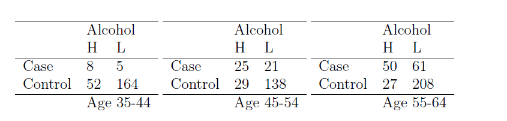

   1. Assuming a constant odds ratio across age-strata, test to see if the odds ratio is 1. If not, estimate it. Interpret results.
   2. Was it reasonable to stratify by age? Why or why not? Answer specifically by considering whether age is a potential confounding factor and what might happen if one did not stratify.
2. Suppose we are interested in comparing the effectiveness of 2 different antibiotics A and B in treating gonorrhea. We match each person receiving antibiotic A with an equivalent person (age within 5 years, same sex) to whom we give antibiotic B and we ask that these persons return to the clinic within 1 week to see if the gonorrhea has been eliminated. Suppose the results are as follows:

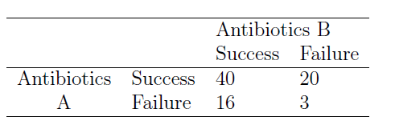

   Perform an analysis to compare the relative effectiveness of the two antibiotics. Interpret your results.
3. Medical records were reviewed to assess the frequency of medical malpractice. Two reviewers classified the same records. We wish to study the agreement between the reviewers. Perform an analysis to assess agreement between the reviewers (+ means classified as malpractice).

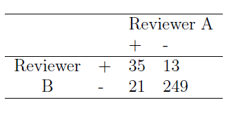

4. 1. A class of 10 students is asked to perform the computer simulation problem of generating 20 90% confidence intervals. Find the probability that all 10 students each have no more than 3 confidence intervals that “miss” (i.e., do not contain the true parameter value) out of 20.
   2. Suppose the class had 100 students and the observed distribution of misses was

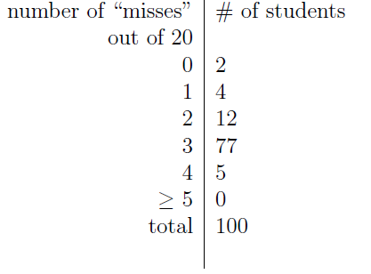

      Is this result consistent with what you would have expected? Give any p-values you think appropriate, and a possible explanation for any unusual result.
5. Obstetric records of a group of children who died suddenly and unexpectedly, S.U.D., were compared with those of a group of live control children. Observations on the duration of the 2nd stage of labour were as follows:

   | Group | Time in minutes |
   | --- | --- |
   | S.U.D. | 60, 25, 6, 8, <5, 10, 25, 15, 10 |
   | Controls | 13, 20, 15, 7, 75, 120*, 10, 100, 9, 25, 30 |

   *Terminated by surgical intervention

   Compare the median duration of labor in the two groups and test the significance of the difference using a nonparametric test.
6. From Question 4 of Homework 1, we know that the proportions of caries free vary area to area. Now we are interested in knowing whether significant differences exist between any pair of areas. Perform multiple comparison procedures of Bonferroni, Sidak, Holm, Hochberg, and Benjamini-Hochberg to judge the significance.